# Gradient descent

Chen Ning Kuan

2020年3月25日

# 1 筆記的目標

- 在這個筆記中，我打算用兩個簡單的例子來實作看看 Gradient descent 如何找到local minimun。
- 我也會展示過大或過小的learning rate會發生甚麼慘況，前者會發生over shooting的狀況，後者則可能停留在不恰當的地方

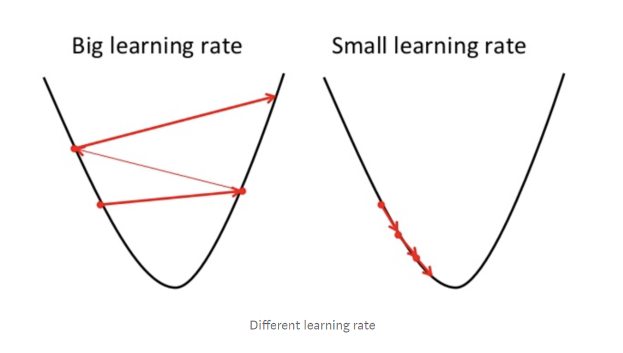

overshooting and small learning rate

- 首先我們常常會遇到一個問題就是要使某個函數$f(\theta)$最小化，$\theta$是我們的參數，我們要找出在$\theta$的值在何處時，會使$f(\theta)$最小，舉例來說如果$f(\theta)=\theta^2+3$ 那麼當theta為0時，我們有最小值3，請注意我們的答案是0而不是3，這點非常重要!
- 我先假定讀者都已經看過Gradient descent的算法，所以我有些地方不會說的太仔細，但我會在該仔細的地方很仔細，其實受限於教學時間的關係，老師上課的時候可能無法代入數字例子，所以我會帶給大家看

# 2 切入正題

## 2.1 目標

- Our goal is to minimize $f(\theta)$ where $\theta$ is a vector or a scalar
- theta它是我們的參數可以有一個或是很多個
- here is the way to updata $\theta$

$$\theta{^{i+1}} \leftarrow \theta{^i}-\eta* \frac{\partial f(\theta{^i})}{\partial\theta^i}$$

- 請注意$i$並非次方的意思，而是第幾次的迭代符號 ，這是一個迭代的算法，你必須要從某個initail guess出發， $\eta$則是所謂的學習率代表要往哪裡走幾步， $\frac{\partial f(\theta{^i})}{\partial\theta^i}$則是我們要往哪裡走的方向!

但是在$\theta$只有一個dim時，方向不是往左就是往右就是了， 而且這件事真的是宇宙無敵直關，你想想看$\eta$是一個正的數字，如果
$$\frac{\partial f(\theta{^i})}{\partial\theta^i}$$

的值為正，代表那個點的切線斜率為正，不就代表往右走一小步的話$f(\theta)$值應該會變大，往左走會變小，這時候$-\eta*\frac{\partial f(\theta{^i})}{\partial\theta^i}$的值是負的!

代表我們要往左走

$\theta{^i}-\eta* \frac{\partial f(\theta{^i})}{\partial\theta^i}$後

$f(\theta{^{i+1}})$真的會變小

反之讀者則可自行驗證

現在我要開始代數字了 ，假設我們的function 很簡單，只有一個參數 $y=f(x)=x^2$ 也就是theta in this case is x. 然後我們的intial guess $x{^1}$ is -3. 為了方便計算學習率$\eta=0.1$， 我們來逐步的代入看看會發生甚麼事情

## 2.2 算法的數字例子

第一步:要先找出$\frac{\partial f(\theta{^i})}{\partial\theta^i}$的形式為何

這裡會微分的朋友就知道 答案是 $2x{^{(i)}}$

第二步:開始代數字啦

所以當 i=1時

$$x{^2}=x{^1}-\eta*\frac{\partial f(x{^i})}{\partial x^i}$$

$$x{^2}=-3-0.1*2*(x{^1})$$
將-3代入$x{^1}$
$$x{^2}=-3-0.1*2*(-3)$$
$$x{^2}=-2.4$$

所以當 i=2時

將-2.4代入$x{^2}$

$$x{^3}=-2.4-0.1*2*(-2.4)$$
$$x{^3}=-1.92$$

剩下的應該可以依此類推了, 最後寫一個寫程式詳細列出這所有的過程

## 2.3 程式碼實作 (函數1)

以下都令$y=f(x)$

我們的函數是 $ min f(x)=x^2$，這個函數的最小值發生在x=0時，其最小值也是$0$

- 讓我們先把函數畫出來

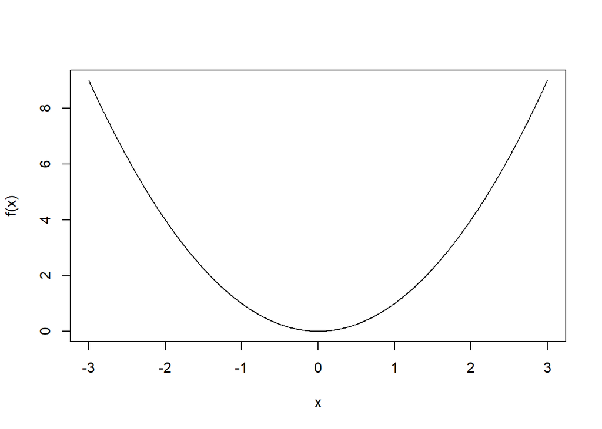

```r
x=seq(-3,3,0.01)
plot(  x,x^2 ,type = "l" ,xlab = "x",ylab = "f(x)"  )
```

- 這裡不使用迭代的收斂條件，而是固定迭代的次數 秀出結果(每次的X和其對應的f(x))

```r
#R is number of iteration
R=10
#eta is learning rate
eta <- 0.1
#intail guess of x
intail_x <- -3
# objective function
f <- function(x) {x^2}
# partial objective function
partialf <-function(x) {2*x}

x=numeric(length=(R+1))
x[1] <-intail_x

for(i in 1:R){

  x[i+1] <- x[i]-eta*partialf(x[i])

}
data.frame(x,y=f(x))
```

```
##             x         y
## 1  -3.0000000 9.0000000
## 2  -2.4000000 5.7600000
## 3  -1.9200000 3.6864000
## 4  -1.5360000 2.3592960
## 5  -1.2288000 1.5099494
## 6  -0.9830400 0.9663676
## 7  -0.7864320 0.6184753
## 8  -0.6291456 0.3958242
## 9  -0.5033165 0.2533275
## 10 -0.4026532 0.1621296
## 11 -0.3221225 0.1037629
```

可以看出我們的算法正確，請讀者去看一下x的值和手算的一樣，而且x也確實隨著迭代的次數增加也會跟著靠近真正的答案0

但是還沒完喔，如果我們的learing rate設的不太好，可能會有以下的慘況

### 2.3.1 if $\eta=1$ in this case

```r
R=10
#eta is learning rate
eta <- 1
#intail guess of x
intail_x <- -3
# objective function
f <- function(x) {x^2}
# partial objective function
partialf <-function(x) {2*x}

x=numeric(length=(R+1))
x[1] <-intail_x

for(i in 1:R){

  x[i+1] <- x[i]-eta*partialf(x[i])

}
data.frame(x,y=f(x))
```

```
##     x y
## 1  -3 9
## 2   3 9
## 3  -3 9
## 4   3 9
## 5  -3 9
## 6   3 9
## 7  -3 9
## 8   3 9
## 9  -3 9
## 10  3 9
## 11 -3 9
```

- 就是互相射來射去又在同一個位置上

### 2.3.2 if $\eta=2$ in this case

```r
R=10
#eta is learning rate
eta <- 2
#intail guess of x
intail_x <- -3
# objective function
f <- function(x) {x^2}
# partial objective function
partialf <-function(x) {2*x}

x=numeric(length=(R+1))
x[1] <-intail_x

for(i in 1:R){

  x[i+1] <- x[i]-eta*partialf(x[i])

}
data.frame(x,y=f(x))
```

```
##          x           y
## 1       -3           9
## 2        9          81
## 3      -27         729
## 4       81        6561
## 5     -243       59049
## 6      729      531441
## 7    -2187     4782969
## 8     6561    43046721
## 9   -19683   387420489
## 10   59049  3486784401
## 11 -177147 31381059609
```

- this is the case called overshooting.就是射太遠了!

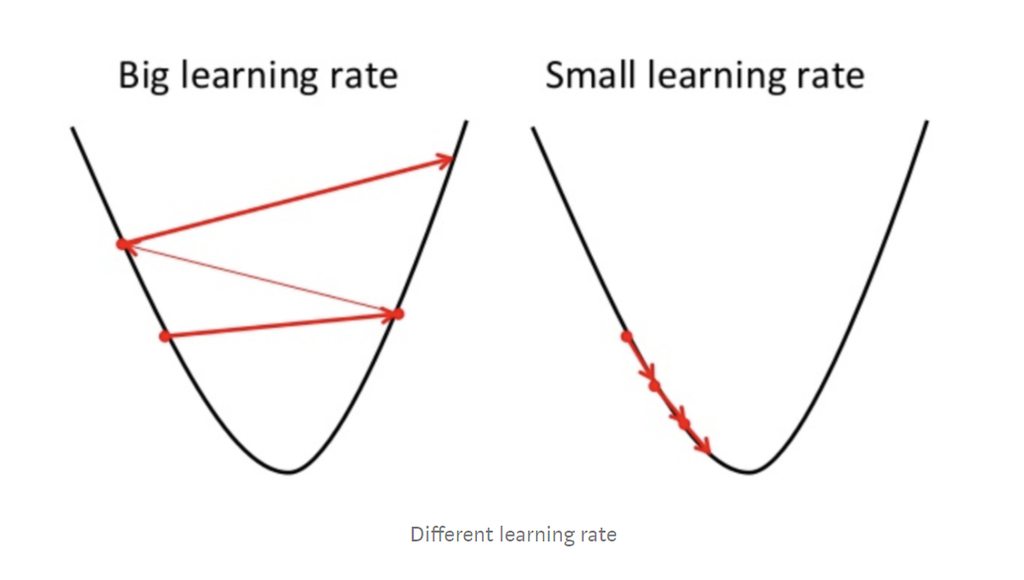

overshooting and small learning rate

- 稍微對照就會發現這就是圖片左邊的overshooting
- 可能會有讀者覺得learning rate越小越好但可以看一下這個以下這個例子

## 2.4 程式碼實作 (函數2)

以下都令$y=f(x)$

我們的目標函數是 $x^4-8*x^3$

這個函數的最小值發生在$x=6$時

其最小值是$-432$

- 讓我們先把函數畫出來

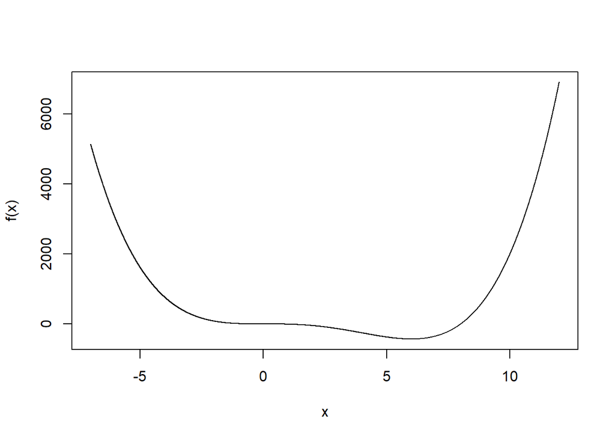

```r
x=seq(-7,12,0.0001)
plot( x ,x^4-8*x^3 ,type = "l" ,xlab = "x",ylab = "f(x)"  )
```

### 2.4.1 case1:

```r
#R is number of iteration
R=35
#eta is learning rate
eta <- 0.001
#intail guess of x
intail_x <- -3
# objective function
f <- function(x) {x^4-8*x^3}
# partial objective function
partialf <-function(x) {4*x^3-24*x^2}
x=numeric(length=(R+1))
x[1] <-intail_x
for(i in 1:R){
  x[i+1] <- x[i]-eta*partialf(x[i])
}
data.frame(x,y=f(x))
```

```
##             x          y
## 1  -3.0000000 297.000000
## 2  -2.6760000 204.581751
## 3  -2.4274855 149.159020
## 4  -2.2288434 113.257036
## 5  -2.0653283  88.673779
## 6  -1.9277150  71.117717
## 7  -1.8098748  58.157944
## 8  -1.7075452  48.331031
## 9  -1.6176533  40.712286
## 10 -1.5379178  34.693883
## 11 -1.4666033  29.862912
## 12 -1.4023629  25.930938
## 13 -1.3441323  22.691595
## 14 -1.2910580  19.994124
```

[output cut: 22 more lines]

- 這裡看出他不小心停留在高原地帶了(x=0附近)

### 2.4.2 case2:

$\eta=0.01$

```r
#R is number of iteration
R=35
#eta is learning rate
eta <- 0.01
#intail guess of x
intail_x <- -3
# objective function
f <- function(x) {x^4-8*x^3}
# partial objective function
partialf <-function(x) {4*x^3-24*x^2}
x=numeric(length=(R+1))
x[1] <-intail_x
for(i in 1:R){
  x[i+1] <- x[i]-eta*partialf(x[i])
}
data.frame(x,y=f(x))
```

```
##             x            y
## 1  -3.0000000  297.0000000
## 2   0.2400000   -0.1072742
## 3   0.2532710   -0.1258563
## 4   0.2680163   -0.1488588
## 5   0.2844860   -0.1776429
## 6   0.3029888   -0.2140927
## 7   0.3239088   -0.2608604
## 8   0.3477295   -0.3217472
## 9   0.3750674   -0.4023130
## 10  0.4067190   -0.5108731
## 11  0.4437288   -0.6601768
## 12  0.4874889   -0.8703206
## 13  0.5398898   -1.1739797
## 14  0.6035505   -1.6261635
```

[output cut: 22 more lines]

- 可以看出在第25次左右就得到了非常好的答案

# 3 總結

- 這裡可以看出learning rate的大小是一個非常重要的議題，其實intial guess也會影響，有興趣的同學可以改改看
- 當$\theta$只有一個dim的實作非常簡單，可惜的是無法體現微分方向的重要性，因為不是往左就是往右
- 要改我的範例也很簡單，只是要手算出partialf的fucntion